# PracaDom9_MBogdańska

Magdalena Bogdańska

Modele liniowe i mieszane

## Task

There is a problem with theoretical formulation of distribution for $\hat\theta$.

But one can use simulations to study this distribution in controlled settings.

The task: simulate distribution of $\hat\theta=\hat\sigma^2_1$ when the true $\sigma^2_1=0$ (all random effects are equal 0) and when $\sigma^2_1=1$.

To simulate distribution of $\hat\sigma^2_1$ one should repeat many times (i.e. 1000) the following scenario:

- simulate $\varepsilon$ and $u$ from Gaussian distribution with given $\sigma^2_0$ and $\sigma^2_1$,
- estimate $\hat\sigma^2_1$ with the use of lme4.

I will construct a mixed-effects models, that is a model of a form:

$y= X \beta + Zu +\varepsilon,$ where $X$ is variable having fixed effect and $Z$ is having random effect, $u \sim \mathcal{N}(0,\sigma_1), \ \epsilon \sim \mathcal{N}(0,\sigma_0).$

In this study I will consider only model of random effect $(X \equiv 0).$ I will consider 12 levels of variable $Z, \sigma_0=5$ and $\sigma_1$ will be equal either 0 or 1.

## Simulation procedure and estimation of $\hat \theta$ for both scenarios

```r
library(lme4)

lev<-12
n_obs<-50
s0<-5

#first scenario
s1_1<-0
# second scenario
s1_2<-1

N<-1000

theta<-replicate(N,{
  Z<-sample(1:lev,n_obs, replace = TRUE)
  eps <- rnorm(n_obs, 0, s0)
  u <- rnorm(n_obs, 0, s1_1)
  u2 <- rnorm(n_obs, 0, s1_2)
  y <- u[Z] + eps
  y2 <- u2[Z] + eps
  rm <- lmer(y~(1|Z)) # random-effects model
  rm2 <- lmer(y2~(1|Z)) # random-effects model
  # extract variance using VarCorr function
  theta<-attr(VarCorr(rm)$Z, "stddev")^2
  # one can alternatively use command:
  # VarCorr(rm)$Z[1]
  theta1<-attr(VarCorr(rm2)$Z, "stddev")^2
  c(theta,theta1)
} )
```

## Visualisation

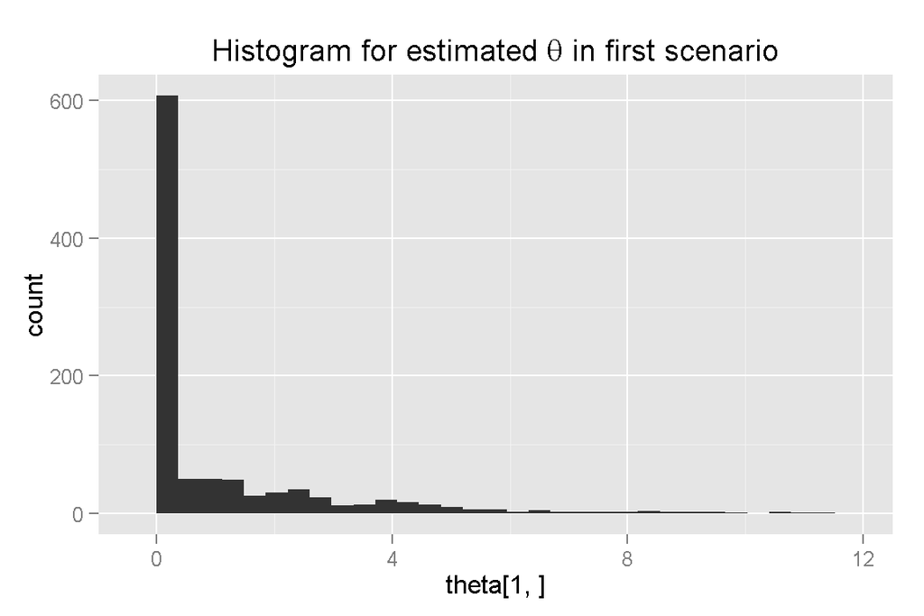

```r
library(ggplot2)
qplot(theta[1,], geom="histogram", main=expression(paste("Histogram for estimated ", theta, " in first scenario")))
```

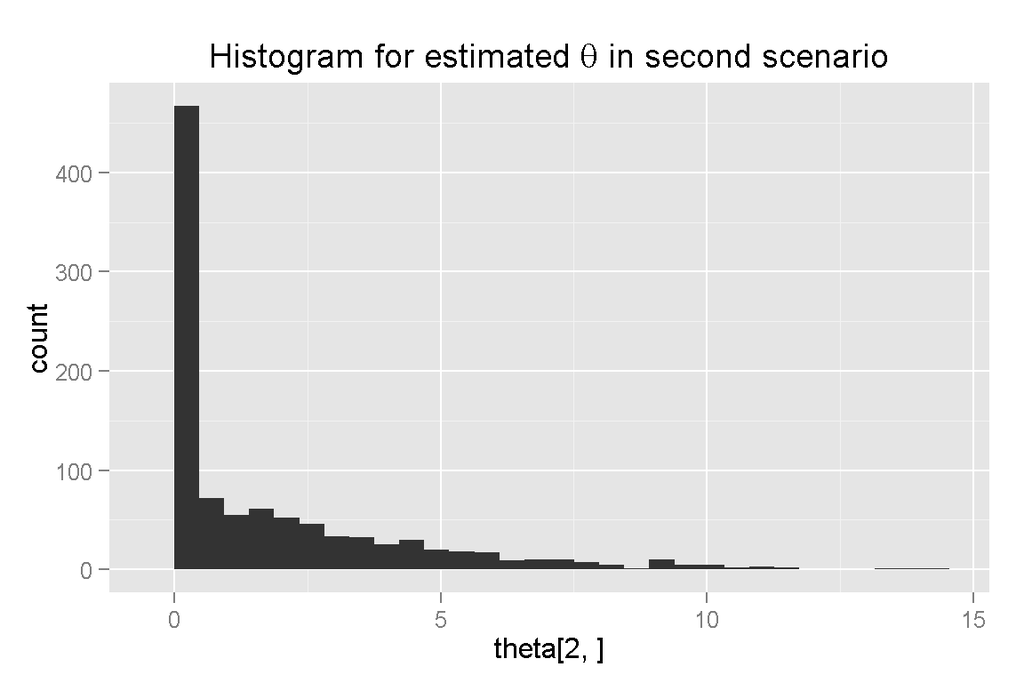

```r
qplot(theta[2,], geom="histogram", main=expression(paste("Histogram for estimated ", theta, " in second scenario")))
```

## Conclusions

The distribution of estimated $\theta$ in both scenario is concentrated around 0, but in the second case the tail is slightly longer and bigger.